# Analysing the effect of land-use type on the proportion of scouts - a *jackknife approach*

Joseph Palmer

```r
ms_mr <- read.csv(file = "data/site_ms_mr.csv")

urban_lu <- urban_lu %>%
  # inner_join(ms_mr, by = "site") %>%
  # select(-ms, -mr, -p.y) %>%
  # rename(p = p_trips) %>%
  # mutate(p = ifelse(p.x == 1, 1, p)) %>%
  mutate(p = 1-p)
  # select(site, p, 3:10)

rural_lu <- rural_lu %>%
  # inner_join(ms_mr, by = "site") %>%
  # select(-ms, -mr, -p.y) %>%
  # rename(p = p_trips) %>%
  # mutate(p = ifelse(p.x == 1, 1, p)) %>%
  mutate(p = 1-p)
  # select(site, p, woodland, 3:12)
```

# TLDR:

A jackknife was carried out on the PLS beta regression whereby each site was excluded from the analysis and the fits to the others established. This was done to assess if a single site biased the model and should be treated as an outlier.

In the urban dataset, site CAD, with a proportion of scouts value of 1 bears the hallmarks of an outlier, the removal of which influences the results of the study more than the removal of any other point. No outliers were identified in the agri-rural dataset.

In addition to showing fits with and without outliers for the urban data, for both environments the jackknifed analysis shows how the loadings vary with each site removed and how the model fits look on the average of the PLS beta values from across the jackknifed analyses. These results suggest the agri-rural data is fairly robust to removing individual sites, however, the urban data is less robust, exemplifying the bias introduced by site CAD. The urban results are overall more volatile than the agri-rural.

In addition, I also plot the loadings to show the amount of area a particular landuse type corresponds to in the total land of all the sites in that environment as a percentage. This allows us to see how much land each land-use type covers. A linear regression between the loadings of PC1 and the amount of land identified shows no significant relationship between the two variables, indicating the amount of land is not influencing the PLS results.

# Jackknife analysis to investigate PLS sensitivity to outliers

Looking over the results of the PLS it is apparent that in the urban PLS the beta regression analysis appears skewed by a single site, CAD, which has a proportion of scouts much higher than the others. It is important to investigate how outliers are influencing our results, particularly in the urban dataset but also with the agri-rural sites. To do this I present an analysis to see if there are any outliers and what effect these have on the results of the PLS and beta regression.

Although site CAD appears to be an outlier, it is prudent to formally establish outliers in both datasets to ensure no other outliers are missed and ensure statistical rigour. To do this I will perform a jackknifed PLS regression to identify how land-use type influences the proportion of scouts estimated from our model. The purpose of the jackknife is to assess how sensitive the results of the PLS are to a given sample and allow for a more robust assessment of any relationship that is skewed by particular sites.

The jackknife will proceed as follows:

A PLS will be be first ran on the full dataset, and then subsets of the data with a single site, $n_i$, removed. Running the PLS on this data yields loadings and the $x$ values for a beta regression to explore the relationship between the primary axis of land-use variation and the proportion of scouts.

Here the land-use categories stay the same, but a single row (site and associated proportion of scouts) is removed. The PLS is then carried out on the remaining data. This results in a loading value for each land-use type and a beta regressor for each site. Once the replicates for $n-1$ data points have been collected (that is, once we have loadings and regressors for the data with each site individually removed) I will examine the distribution of slope values identified from the beta regression. I will also the plot the distribution of the loading values for each land-use type as a box plot to see how they vary in relation to the included sites. We also then take all the regressor values and calculate the median of these values for each site. These medians are then compared against the proportion of scouts in a beta regression.

## Urban jackknife

Starting with the urban dataset, the data is first jackknifed and the metrics reported and discussed in turn.

### Identifying outlier sites from the slopes of the jackknifed beta regression

After running the beta regression of the jackknifed data we can formally assess outliers by examining the distribution of slopes identified with each site removed.

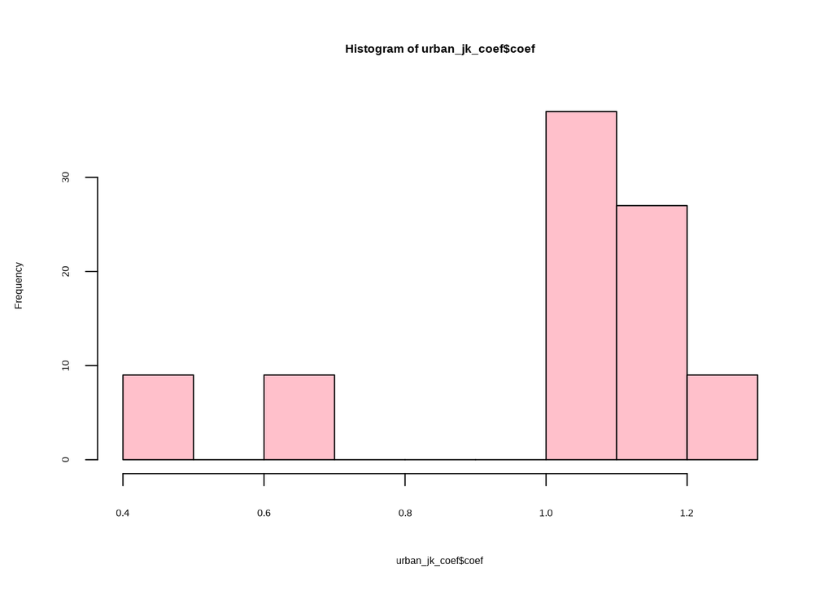

Now lets see what this slope references to.

[output not shown]

The site missing from this dataset is CAD. This is what I would have expected, but it is good to establish this formally. The next task is to now look at how the loadings and betaregression fit looks with and without the inclusion of this site.

```
#> [1] "Full data beta regression"
```

```
#>
#> Call:
#> betareg(formula = prop.scouts ~ pc1, data = plsdata)
#>
#> Standardized weighted residuals 2:
#>     Min      1Q  Median      3Q     Max
#> -1.9686 -0.9646 -0.4554  0.8617  1.6953
#>
#> Coefficients (mean model with logit link):
#>             Estimate Std. Error z value Pr(>|z|)
#> (Intercept)   0.9530     0.2266   4.205 2.61e-05 ***
#> pc1           1.0715     0.2351   4.557 5.19e-06 ***
#>
#> Phi coefficients (precision model with identity link):
#>       Estimate Std. Error z value Pr(>|z|)
#> (phi)   10.426      4.607   2.263   0.0236 *
#> ---
#> Signif. codes:  0 '***' 0.001 '**' 0.01 '*' 0.05 '.' 0.1 ' ' 1
#>
#> Type of estimator: ML (maximum likelihood)
#> Log-likelihood: 8.097 on 3 Df
#> Pseudo R-squared: 0.7328
#> Number of iterations: 18 (BFGS) + 4 (Fisher scoring)
```

[output not shown]

```
#> [1] "Outlier removed beta regression"
```

```
#>
#> Call:
#> betareg(formula = prop.scouts ~ pc1, data = plsdata)
#>
#> Standardized weighted residuals 2:
#>     Min      1Q  Median      3Q     Max
#> -2.1212 -0.9158  0.0266  0.6214  2.2188
#>
#> Coefficients (mean model with logit link):
#>             Estimate Std. Error z value Pr(>|z|)
#> (Intercept)   0.7161     0.2620   2.733  0.00627 **
#> pc1           0.6857     0.2136   3.210  0.00133 **
#>
#> Phi coefficients (precision model with identity link):
#>       Estimate Std. Error z value Pr(>|z|)
#> (phi)    7.058      3.213   2.196   0.0281 *
#> ---
#> Signif. codes:  0 '***' 0.001 '**' 0.01 '*' 0.05 '.' 0.1 ' ' 1
#>
#> Type of estimator: ML (maximum likelihood)
#> Log-likelihood:  5.17 on 3 Df
#> Pseudo R-squared: 0.6326
#> Number of iterations: 18 (BFGS) + 4 (Fisher scoring)
```

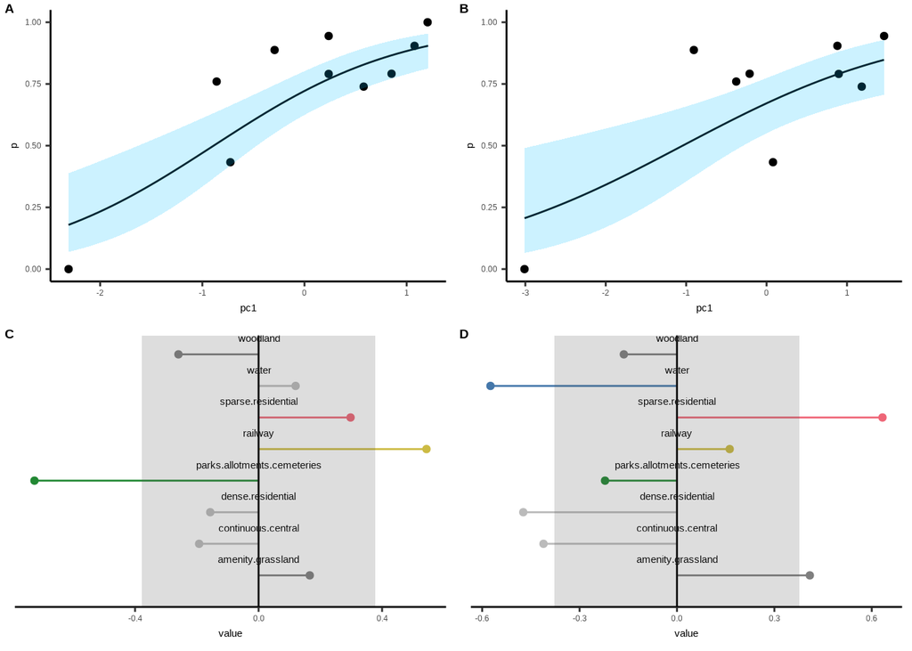

Overall, this result shows the urban dataset is vulnerable to the site CAD, which seems to be acting as an outlier.

### Examining how the loadings and fit changes through the jackknifed analysis

The jacknife computes a PLS beta regression for the sample with each site removed. It is thus possible to observe how the loadings change with each site removed and also to look at the regression fit of the average of the regressors outlined from the beta regressions run over the data.

```
#>
#> Call:
#> betareg(formula = prop.scouts ~ pc1, data = urban_median_pls_data)
#>
#> Standardized weighted residuals 2:
#>     Min      1Q  Median      3Q     Max
#> -1.8156 -0.9846 -0.4686  0.9811  1.6745
#>
#> Coefficients (mean model with logit link):
#>             Estimate Std. Error z value Pr(>|z|)
#> (Intercept)   0.9313     0.2168   4.296 1.74e-05 ***
#> pc1           1.1115     0.2346   4.737 2.17e-06 ***
#>
#> Phi coefficients (precision model with identity link):
#>       Estimate Std. Error z value Pr(>|z|)
#> (phi)    11.48       5.08   2.259   0.0239 *
#> ---
#> Signif. codes:  0 '***' 0.001 '**' 0.01 '*' 0.05 '.' 0.1 ' ' 1
#>
#> Type of estimator: ML (maximum likelihood)
#> Log-likelihood: 8.566 on 3 Df
#> Pseudo R-squared: 0.7614
#> Number of iterations: 26 (BFGS) + 4 (Fisher scoring)
```

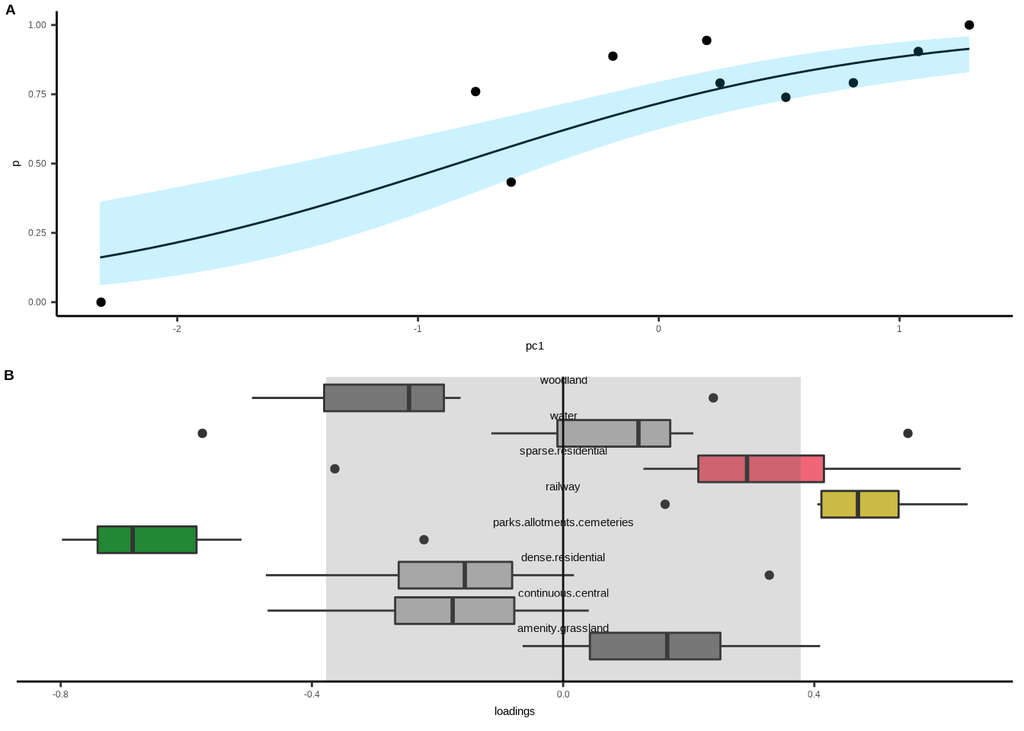

## Further analysis of sensitivity to site removal and landuse proportions: digging into the the distributions of PLS loadings

Here I show the loadings for each jackknife itteration, that is each PLS ran with a specific site removed. The following plot shows abreak down of the boxplots shown previously.

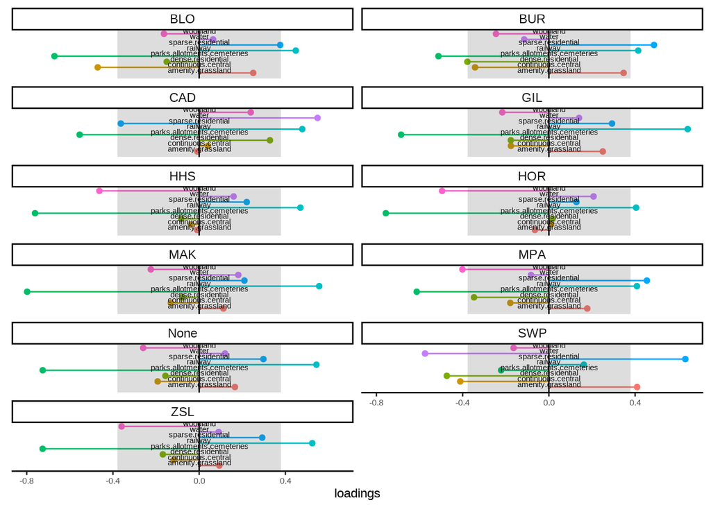

There is a fair amount of variation in these plots, more than is shown with the boxplots for sure. Many landuse types move around in an out of being significant depending on what site is removed, but parks allotments and cemeteries and sparse residential remain relatively consistent in their position, except for when CAD is removed.

## How does this compare with the proportion of land-coverage for each site?

I now recreate the main plot but using the percentage of total area that covers as the argument to the size parameter. for the plot.

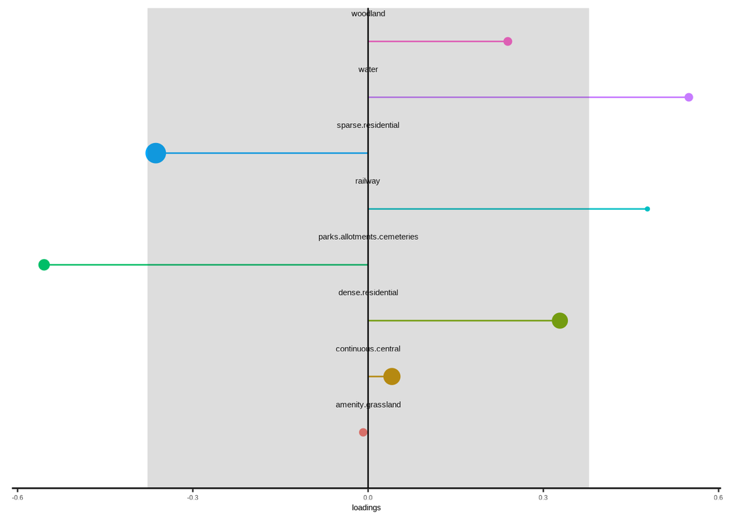

```
#> # A tibble: 8 × 7
#>   landuse_type             loadings p_removed site_removed cutoff  area area_pct
#>   <chr>                       <dbl>     <dbl> <chr>         <dbl> <dbl>    <dbl>
#> 1 sparse.residential       -0.363        0.05 CAD           0.378 347.     38.6
#> 2 continuous.central        0.0408       0.05 CAD           0.378 214.     23.8
#> 3 dense.residential         0.328        0.05 CAD           0.378 182.     20.2
#> 4 parks.allotments.cemete… -0.555        0.05 CAD           0.378  66.9     7.43
#> 5 woodland                  0.239        0.05 CAD           0.378  28.8     3.20
#> 6 water                     0.549        0.05 CAD           0.378  26.9     2.99
#> 7 amenity.grassland        -0.00835      0.05 CAD           0.378  24.8     2.75
#> 8 railway                   0.478        0.05 CAD           0.378   9.7     1.08
```

As we can see from the graph and the table, sparse residential coveres the most land, around 39%. Parks allotments and cemeteries describes around 8% of the land, whilst water explains around 3%. Railway, a singificant contributor, accounts just 1% of the total land area.

It is also important to check if there is a correlation between the loadings and the area for each landuse type. This was done using a linear model between the loadings for PC1 and the area associated with that landuse type.

```
#>
#> Call:
#> lm(formula = area ~ loadings, data = urban_lu_loadings_with_area)
#>
#> Residuals:
#>     Min      1Q  Median      3Q     Max
#> -134.71  -72.44  -35.37   96.91  172.15
#>
#> Coefficients:
#>             Estimate Std. Error t value Pr(>|t|)
#> (Intercept)   124.80      43.12   2.894   0.0275 *
#> loadings     -138.51     114.42  -1.211   0.2716
#> ---
#> Signif. codes:  0 '***' 0.001 '**' 0.01 '*' 0.05 '.' 0.1 ' ' 1
#>
#> Residual standard error: 118.6 on 6 degrees of freedom
#> Multiple R-squared:  0.1963, Adjusted R-squared:  0.06234
#> F-statistic: 1.465 on 1 and 6 DF,  p-value: 0.2716
```

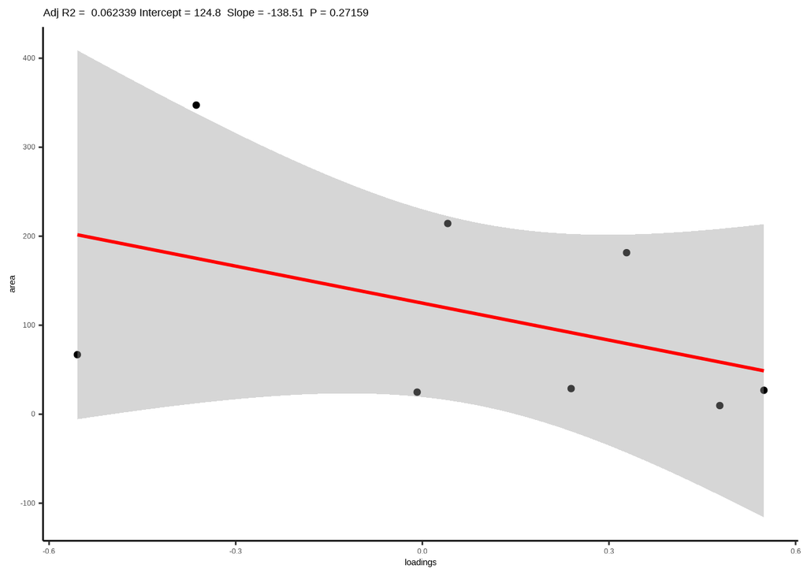

The results show no significant correlation, indicating the amount of land in each landuse type catagory is not influencing the model results.

### Conclusions

Site CAD seems to be having a large effect on the results of the PLS. The jackknife analysis shows this site skews the slopes more than the others. Plotting the averages of the PLS provides a means of seeing how the PLS results change in relation to removing sites. They seem fairly robust to site removals, but this could also mean site CAD is heavily influencing the relationship.

I am not sure if plotting the averages adds anything and it could be making some questionable assumptions if we really dig into this. The fact that the PLS slope changes greatly with CAD removed, whereas the others dont as much, suggests that this site should be excluded from the PLS analysis and the result without it used.

## Agri-rural PLS

Although the agri-rural data doesnt show any ovbious outliers it is prudent to check it with a jackknife to be sure. The first thing to do is look at a histogram of the slopes to see if any one site greatly influences it.

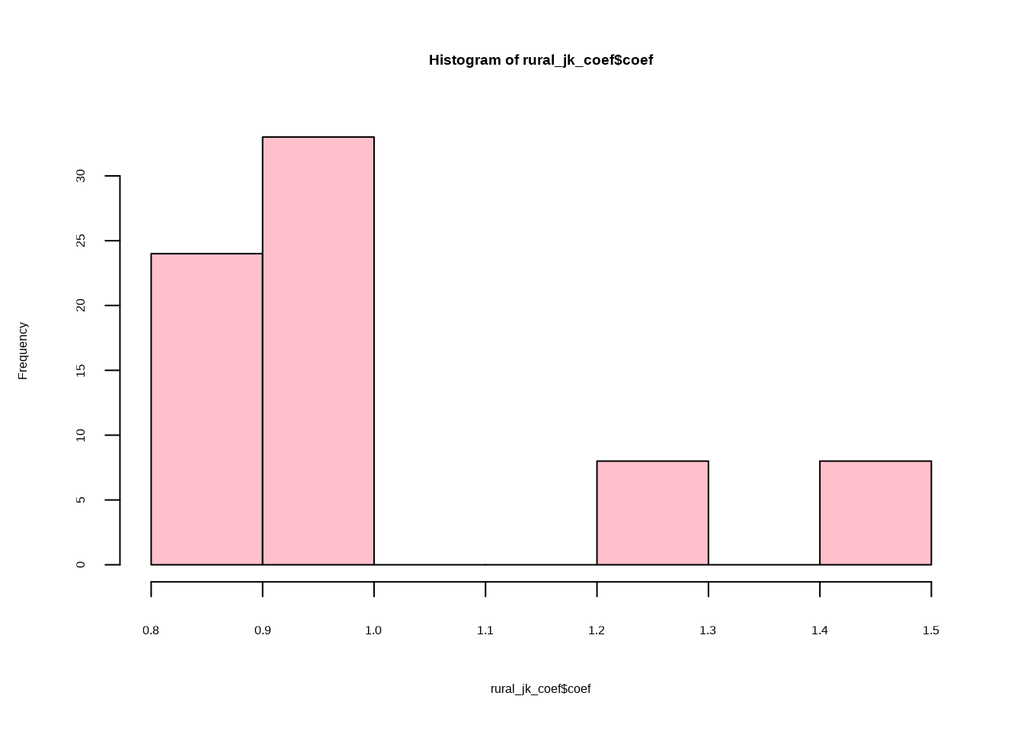

### Examining how the loadings and fit changes through the jackknifed analysis

Although we did not see any outliers from the jackknife, it would still be usefull to evaluate the distribution of loadings and median model fit from the jackknifed analysis, as we did for the urban dataset. This will show us if the results change much accross the jackknifes.

```
#>
#> Call:
#> betareg(formula = prop.scouts ~ pc1, data = rural_median_pls_data)
#>
#> Standardized weighted residuals 2:
#>     Min      1Q  Median      3Q     Max
#> -1.8150 -0.7504 -0.0163  1.0270  1.6654
#>
#> Coefficients (mean model with logit link):
#>             Estimate Std. Error z value Pr(>|z|)
#> (Intercept)   0.1228     0.2913   0.422    0.673
#> pc1           1.0629     0.2323   4.576 4.73e-06 ***
#>
#> Phi coefficients (precision model with identity link):
#>       Estimate Std. Error z value Pr(>|z|)
#> (phi)    5.501      2.635   2.087   0.0369 *
#> ---
#> Signif. codes:  0 '***' 0.001 '**' 0.01 '*' 0.05 '.' 0.1 ' ' 1
#>
#> Type of estimator: ML (maximum likelihood)
#> Log-likelihood: 6.474 on 3 Df
#> Pseudo R-squared: 0.7552
#> Number of iterations: 25 (BFGS) + 5 (Fisher scoring)
```

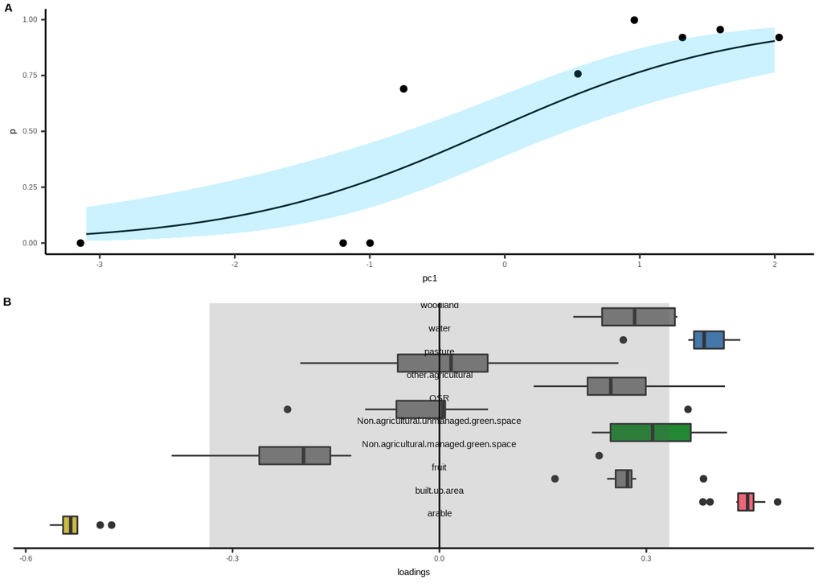

Compared to the same plots for the urban site, the distributions are much tighter, and although there are still individual outliers, it seems that the jackknife shows our results don’t change much when sites are excluded.

## Further analysis of sensitivity to site removal and landuse proportions: digging into the the distributions of PLS loadings

Here I show the loadings for each jackknife itteration, that is each PLS ran with a specific site removed. The following plot shows abreak down of the boxplots shown previously.

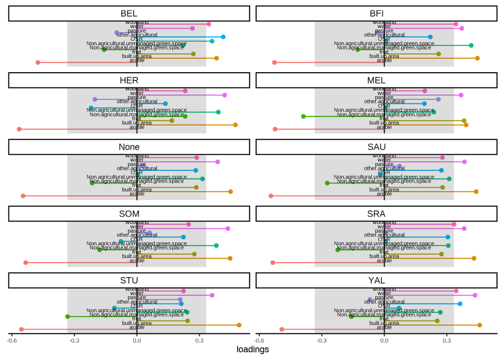

There is a fair amount of variation in these plots, more than is shown with the boxplots for sure. Many landuse types move around in an out of being significant depending on what site is removed, but many, such as arable and built up areas, remain consistent in their position.

## How does this compare with the proportion of land-coverage for each site?

I now recreate the main plot but using the percentage of total area that covers as the argument to the size parameter. for the plot.

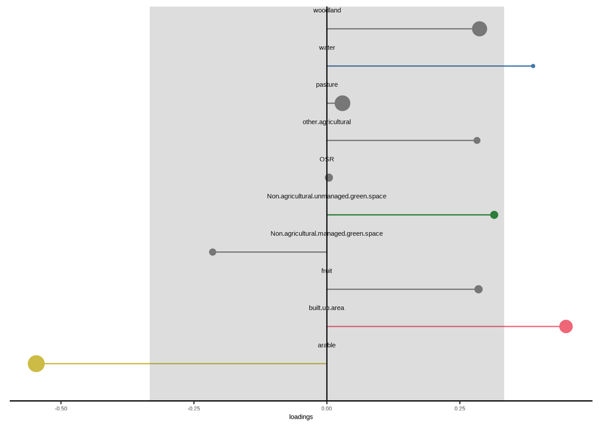

```
#> # A tibble: 10 × 7
#>    landuse_type            loadings p_removed site_removed cutoff  area area_pct
#>    <chr>                      <dbl>     <dbl> <chr>         <dbl> <dbl>    <dbl>
#>  1 arable                  -0.546           0 None          0.333 255     28.3
#>  2 pasture                  0.0293          0 None          0.333 210     23.3
#>  3 woodland                 0.287           0 None          0.333 190.    21.1
#>  4 built.up.area            0.450           0 None          0.333 135.    15.0
#>  5 fruit                    0.285           0 None          0.333  27.7    3.08
#>  6 OSR                      0.00383         0 None          0.333  26.1    2.90
#>  7 Non.agricultural.unman…  0.315           0 None          0.333  25.3    2.81
#>  8 Non.agricultural.manag… -0.215           0 None          0.333  15.8    1.76
#>  9 other.agricultural       0.282           0 None          0.333  13.5    1.50
#> 10 water                    0.388           0 None          0.333   1.6    0.178
```

It is also important to check if there is a correlation between the loadings and the area for each landuse type. This was done using a linear model between the loadings for PC1 and the area associated with that landuse type.

```
#>
#> Call:
#> lm(formula = area ~ loadings, data = rural_lu_loadings_with_area)
#>
#> Residuals:
#>     Min      1Q  Median      3Q     Max
#> -119.49  -55.56  -40.74   84.86  120.67
#>
#> Coefficients:
#>             Estimate Std. Error t value Pr(>|t|)
#> (Intercept)   106.89      32.12   3.328   0.0104 *
#> loadings     -132.22      99.58  -1.328   0.2209
#> ---
#> Signif. codes:  0 '***' 0.001 '**' 0.01 '*' 0.05 '.' 0.1 ' ' 1
#>
#> Residual standard error: 93.26 on 8 degrees of freedom
#> Multiple R-squared:  0.1806, Adjusted R-squared:  0.07814
#> F-statistic: 1.763 on 1 and 8 DF,  p-value: 0.2209
```

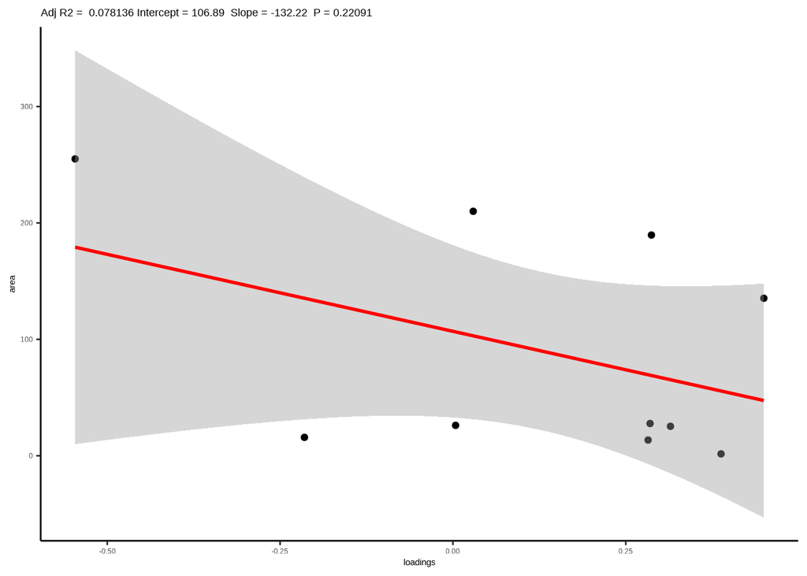

The results show no significant correlation, indicating the amount of land in each landuse type catagory is not influencing the model results.